# Donor Profile: European Commission - Neighbourhood and Enlargement Negotiations

## Focus Portfolio

The European Commission’s 2025 funding portfolio for UNHCR displays significant variance, with average donor contributions around $11.3 million but extremes ranging from $70,000 to nearly $110 million. This disparity signals untapped opportunities to scale investments in underfunded regions within Europe and Neighbourhood areas, potentially enhancing emergency response and resilience outcomes. Strategic funding concentration on smaller allocation zones could act as an impact multiplier by addressing critical gaps, improving program reach, and strengthening partnerships in regions where modest increases yield outsized benefits. Immediate donor investment is essential to leverage these variances and balance funding distribution effectively. UNHCR recommends positioning these funding disparities as a compelling call to action for targeted donor engagement, emphasizing partnership opportunities that maximize return on investment through strategic resource allocation. Capitalizing on this data can guide resource prioritization, mitigate risks of underfunding, and optimize accountability frameworks, advancing UNHCR’s commitment to sustainable solutions. Decision-makers should prioritize closing funding gaps by incentivizing contributions to less supported regions, reinforcing multilateral cooperation, and integrating innovation for scalable impact.

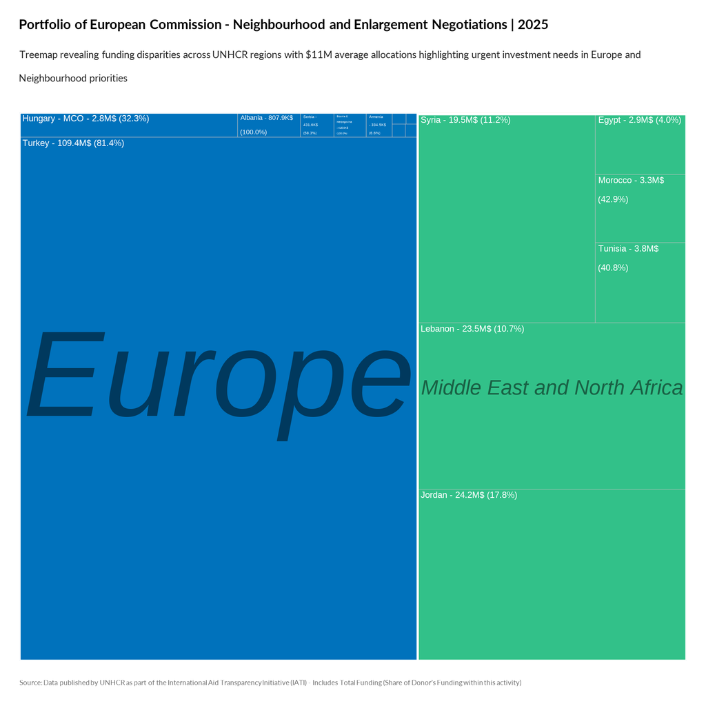

TRUE

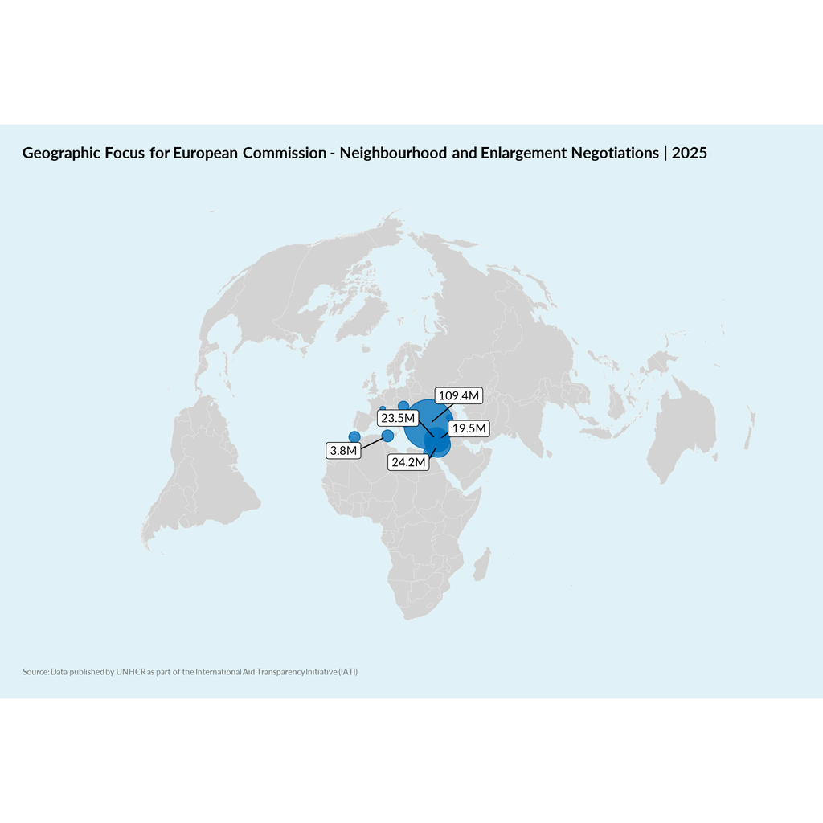

TRUE